# 2 Geocoding Locations

## 2.1 Overview

A common goal in opioid environment research is to calculate and compare access metrics to different providers of Medications for Opioid Overuse Disorder (MOUDs). Before we can run any analytics on the resource location data, we need to convert resource addresses to spatial data points, which can be then used to calculate access metrics.

**Geocoding** is the process of converting addresses (like a street address) into geographic coordinates using a known coordinate reference system. We can then use these coordinates (latitude, longitude) to spatially enable our data. This means we convert to a spatial data frame (sf) within R for spatial analysis within our R session, and then save as a shapefile (a spatial data format) for future use. In this tutorial we demonstrate how to geocode resource location addresses and convert to spatial data points that can be used for future mapping and geospatial analysis.

Our objectives are thus to:

- Geocode addresses to get geographic coordinates
- Visualize the resource locations as points on a map in R
- Transform a flat file (.CSV) to a spatially enabled shapefile (.SHP)

## 2.2 Environment Setup

To replicate the code & functions illustrated in this tutorial, you’ll need to have R and RStudio downloaded and installed on your system. This tutorial assumes some familiarity with the R programming language.

### 2.2.1 Input/Output

We will convert these addresses to geographic coordinates using an appropriate coordinate reference system (CRS), and then spatially enable the data for mapping. We will then export the spatial dataframe as a **shapefile**.

### 2.2.2 Load Libraries

We will use the following packages in this tutorial:

- `sf`: to manipulate spatial data
- `tmap`: to visualize and create maps
- `tidygeocoder`: to convert addresses to geographic coordinates

Then load the libraries for use.

```r
library(sf)
library(tidygeocoder)
library(tmap)
```

### 2.2.3 Load Data

We will use a CSV that includes methadone clinic addresses in Chicago as an example. We start with a small dataset to test our geocoding workflow, as best practice.

Let’s take a look at the first few rows of the dataset. Our data includes addresses but not geographic coordinates.

```r
methadoneClinics <- read.csv("data/chicago_methadone_nogeometry.csv")
head(methadoneClinics)
```

```
  X                                                         Name
1 1                Chicago Treatment and Counseling Center, Inc.
2 2                      Sundace Methadone Treatment Center, LLC
3 3 Soft Landing Interventions/DBA Symetria Recovery of Lakeview
4 4                                        PDSSC - Chicago, Inc.
5 5                          Center for Addictive Problems, Inc.
6 6                                Family Guidance Centers, Inc.
                  Address    City State   Zip
1 4453 North Broadway st. Chicago    IL 60640
2 4545 North Broadway St. Chicago    IL 60640
3    3934 N. Lincoln Ave. Chicago    IL 60613
4     2260 N. Elston Ave. Chicago    IL 60614
5        609 N. Wells St. Chicago    IL 60654
6     310 W. Chicago Ave. Chicago    IL 60654
```

## 2.3 Geocode addresses

### 2.3.1 Quality Control

Before geocoding, perform an initial quality check on the data. Note that the address, city, state, and zip code are all separated as different columns. This will make it easier to stitch together for a coherent, standard address for geocoding. Furthermore, there do not appear to be any major errors. The city name “Chicago” is spelled consistently, without missing addresses or zip codes. This will not always be the case, unfortunately. Data must be cleaned prior to loading into a geocoding service.

### 2.3.2 Selecting Geocoding Service

To get a geographic coordinate for each site, we’ll need to geocode. There are a number of geocoding options in R; here we use we the `tidygeocoder` package. It uses [mutliple geocoding services](https://jessecambon.github.io/tidygeocoder/articles/geocoder_services.html), providing the user with an option to choose. It also provides the option to use a `osm` method which uses the Nominatum service, allowing 1 query per second. More powerful services are available that are even more effective for batch geocoding (i.e. larger volume of addresses). Many will require an API key, necessitating registration and additional funds to purchase access in some cases.

When considering which geocoding service to use, consider scale and potential geocoding errors. Some geocoding services are more accurate than others, so if your coordinates were not coded precisely, try a different service. If you have thousands of addresses to geocode, you may require more complex data pipelines. For an open option with no API key required, you can try the [US Census geocoder](https://geocoding.geo.census.gov/) (or `census` method in this package), which allows around 10,000 addresses to be geocoded at once. Others have varying daily limits. Google Maps API and ESRI Geocoding service are additional high-quality geocoding services with varying cost associated, both within and outside this package.

**Is your data private?**

If you are working with private data that has additional protections, you should not use a geocoding service that is connected to the internet. Because addresses are being passed through a web service, it is not considered protected. That includes the geocoding services presented in `tidygeocoder`!

For protected data, you must use a HIPAA-compliant geocoding service that works offline. You can build one through Nominatum (see example [here](https://mapscaping.com/open%E2%80%91source-geocoding-with-nominatim-and-geopy/)), use an ESRI partner product (see example [here](https://www.esri.com/partners/spatialitics-a2Tf20000056o9TEAQ/healthcare-geocoder-a2df2000004MiL4AAK)), or check out additional options.

### 2.3.3 Test Geocoding Service

Before geocoding your entire dataset, first review the documentation for the geocoding service you’ll be using. In our example we use `tidygeocoder`, with documentation found [here](https://cran.r-project.org/web/packages/tidygeocoder/vignettes/tidygeocoder.html). Let’s test the service by starting with one address:

```r
sample <- geo("4545 North Broadway St. Chicago, IL", lat = latitude, long = longitude, method = 'osm')
```

```
Passing 1 address to the Nominatim single address geocoder
```

```
Query completed in: 2.3 seconds
```

```r
sample
```

```
# A tibble: 1 × 3
  address                             latitude longitude
  <chr>                                  <dbl>     <dbl>
1 4545 North Broadway St. Chicago, IL     42.0     -87.7
```

What did the output look like? Get familiar with the input parameters, expected output, and review the documentation further if needed.

### 2.3.4 Prepare input parameter

To apply the function to multiple addresses, we first we need ensure that we have a *character vector* of full addresses.

```r
str(methadoneClinics)
```

```
'data.frame':   27 obs. of  6 variables:
 $ X      : int  1 2 3 4 5 6 7 8 9 10 ...
 $ Name   : chr  "Chicago Treatment and Counseling Center, Inc." "Sundace Methadone Treatment Center, LLC" "Soft Landing Interventions/DBA Symetria Recovery of Lakeview" "PDSSC - Chicago, Inc." ...
 $ Address: chr  "4453 North Broadway st." "4545 North Broadway St." "3934 N. Lincoln Ave." "2260 N. Elston Ave." ...
 $ City   : chr  "Chicago" "Chicago" "Chicago" "Chicago" ...
 $ State  : chr  "IL" "IL" "IL" "IL" ...
 $ Zip    : int  60640 60640 60613 60614 60654 60654 60651 60607 60607 60616 ...
```

Next we convert all fields to character first to avoid issues with factors (a common peril of R!).

```r
methadoneClinics$fullAdd <- paste(as.character(methadoneClinics$Address),
                                  as.character(methadoneClinics$City),
                                  as.character(methadoneClinics$State),
                                  as.character(methadoneClinics$Zip))
head(methadoneClinics)
```

```
  X                                                         Name
1 1                Chicago Treatment and Counseling Center, Inc.
2 2                      Sundace Methadone Treatment Center, LLC
3 3 Soft Landing Interventions/DBA Symetria Recovery of Lakeview
4 4                                        PDSSC - Chicago, Inc.
5 5                          Center for Addictive Problems, Inc.
6 6                                Family Guidance Centers, Inc.
                  Address    City State   Zip
1 4453 North Broadway st. Chicago    IL 60640
2 4545 North Broadway St. Chicago    IL 60640
3    3934 N. Lincoln Ave. Chicago    IL 60613
4     2260 N. Elston Ave. Chicago    IL 60614
5        609 N. Wells St. Chicago    IL 60654
6     310 W. Chicago Ave. Chicago    IL 60654
                                   fullAdd
1 4453 North Broadway st. Chicago IL 60640
2 4545 North Broadway St. Chicago IL 60640
3    3934 N. Lincoln Ave. Chicago IL 60613
4     2260 N. Elston Ave. Chicago IL 60614
5        609 N. Wells St. Chicago IL 60654
6     310 W. Chicago Ave. Chicago IL 60654
```

### 2.3.5 Batch Geocoding

```r
geoCodedClinics <- methadoneClinics %>%
                            geocode(address = 'fullAdd',
                                    lat = latitude,
                                    long = longitude,
                                    method = 'osm')
```

```
Passing 27 addresses to the Nominatim single address geocoder
```

```
Query completed in: 27.8 seconds
```

```r
geoCodedClinics
```

```
# A tibble: 27 × 9
       X Name               Address City  State   Zip fullAdd latitude longitude
   <int> <chr>              <chr>   <chr> <chr> <int> <chr>      <dbl>     <dbl>
 1     1 "Chicago Treatmen… 4453 N… Chic… IL    60640 4453 N…     42.0     -87.7
 2     2 "Sundace Methadon… 4545 N… Chic… IL    60640 4545 N…     42.0     -87.7
 3     3 "Soft Landing Int… 3934 N… Chic… IL    60613 3934 N…     42.0     -87.7
 4     4 "PDSSC - Chicago,… 2260 N… Chic… IL    60614 2260 N…     41.9     -87.7
 5     5 "Center for Addic… 609 N.… Chic… IL    60654 609 N.…     41.9     -87.6
 6     6 "Family Guidance … 310 W.… Chic… IL    60654 310 W.…     41.9     -87.6
 7     7 "A Rincon Family … 3809 W… Chic… IL    60651 3809 W…     41.9     -87.7
 8     8 "*"                140 N.… Chic… IL    60607 140 N.…     41.9     -87.7
 9     9 "Healthcare Alter… 210 N.… Chic… IL    60607 210 N.…     41.9     -87.7
10    10 "Specialized Assi… 2630 S… Chic… IL    60616 2630 S…     41.8     -87.6
# ℹ 17 more rows
```

**Nulls in your data?**

At this stage, you’ll want to check for any null values. If there are any NAs in your dataset due to faulty address location information and/or unsuccessful geocoding, you will need to correct and/or remove the nulls before proceeding.

## 2.4 Convert to Spatial Data

While we have geographic coordinates loaded in our data, it is still not spatially enabled. To convert to a spatial data format, we have to enable to coordinate reference system that connects the latitude and longitude recorded to actual points on Earth.

### 2.4.1 Spatial Reference Systems

There are thousands of ways to model the Earth, and each requires a different spatial reference system. This is a very complicated domain of spatial applications (for a primer [see here](https://developers.arcgis.com/documentation/core-concepts/spatial-references)), but for our purposes, we simplify by using a geodetic CRS that uses coordinates longitude and latitude. Not all coordinates will appear as a latitude/longitude, however, so it’s important to at least check for the CRS used when working with geographic data. The lat/long coordinates provided by the geocoding service we used report data using the CRS coded as **4326**, a World Geodetic System (WGS84) model also used by Google Earth and many other applications. In this system, distance is measured as degrees and distorted. So while useful for visualizing points, we will need to convert to another CRS for other types of spatial analysis.

### 2.4.2 Enable Points

Next we convert our dataframe to a spatial data frame using the `st_as_sf()` function. The `coords` argument specifies which two columns are the X and Y for your data. We set the crs argument equal to 4326.

*Please note longitude is entered as first column rather than the latitude. It is a very common mistake.* The X, Y field actually refers to longitude, latitude.

```r
methadoneSf <- st_as_sf(geoCodedClinics,
                        coords = c("longitude", "latitude"),
                        crs = 4326)
head(data.frame(methadoneSf))
```

```
  X                                                         Name
1 1                Chicago Treatment and Counseling Center, Inc.
2 2                      Sundace Methadone Treatment Center, LLC
3 3 Soft Landing Interventions/DBA Symetria Recovery of Lakeview
4 4                                        PDSSC - Chicago, Inc.
5 5                          Center for Addictive Problems, Inc.
6 6                                Family Guidance Centers, Inc.
                  Address    City State   Zip
1 4453 North Broadway st. Chicago    IL 60640
2 4545 North Broadway St. Chicago    IL 60640
3    3934 N. Lincoln Ave. Chicago    IL 60613
4     2260 N. Elston Ave. Chicago    IL 60614
5        609 N. Wells St. Chicago    IL 60654
6     310 W. Chicago Ave. Chicago    IL 60654
                                   fullAdd                   geometry
1 4453 North Broadway st. Chicago IL 60640 POINT (-87.65981 41.97436)
2 4545 North Broadway St. Chicago IL 60640 POINT (-87.65981 41.97562)
3    3934 N. Lincoln Ave. Chicago IL 60613 POINT (-87.67844 41.95327)
4     2260 N. Elston Ave. Chicago IL 60614 POINT (-87.67425 41.92263)
5        609 N. Wells St. Chicago IL 60654 POINT (-87.63379 41.89271)
6     310 W. Chicago Ave. Chicago IL 60654   POINT (-87.6364 41.8968)
```

Note that this is a data frame, but that it has a final column called “geometry” that stores the spatial information.

### 2.4.3 Visualize Points

We plot our points as dots, and add the basemap. It is plotting in Chicago as expected!

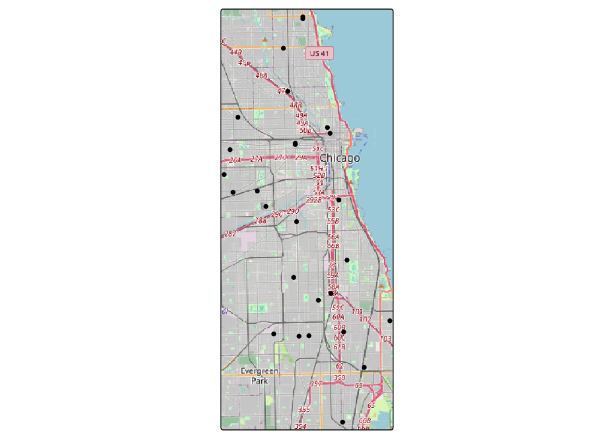

```r
tm_shape(methadoneSf) + tm_dots() + tm_basemap("OpenStreetMap")
```

### 2.4.4 Save Data

Finally, we save this spatial dataframe as a shapefile which can be used for further spatial analysis.

```r
write_sf(methadoneSf, "data/methadone_clinics.shp")
```